# Machine Learning Course Project

Robert W Allen

March 9, 2016

## Download and Clean Testing and Training Data for Project

Download the Testing and Training Data from the web.

```r
train_url <- "https://d396qusza40orc.cloudfront.net/predmachlearn/pml-training.csv"
download.file(train_url, "pml-training.csv")
raw_train_data <- read.csv("pml-training.csv", na.strings = c("NA", ""))

test_url <- "https://d396qusza40orc.cloudfront.net/predmachlearn/pml-testing.csv"
download.file(test_url, "pml-testing.csv")
raw_test_data <- read.csv("pml-testing.csv", na.strings = c("NA", ""))
```

## Descriptive Analysis

Before we can begin the anlaysis we need to understand the variables, especially the one one we hope to predict, classe.

```r
head(raw_train_data)
```

```
##   X user_name raw_timestamp_part_1 raw_timestamp_part_2   cvtd_timestamp
## 1 1  carlitos           1323084231               788290 05/12/2011 11:23
## 2 2  carlitos           1323084231               808298 05/12/2011 11:23
## 3 3  carlitos           1323084231               820366 05/12/2011 11:23
## 4 4  carlitos           1323084232               120339 05/12/2011 11:23
## 5 5  carlitos           1323084232               196328 05/12/2011 11:23
## 6 6  carlitos           1323084232               304277 05/12/2011 11:23
##   new_window num_window roll_belt pitch_belt yaw_belt total_accel_belt
## 1         no         11      1.41       8.07    -94.4                3
## 2         no         11      1.41       8.07    -94.4                3
## 3         no         11      1.42       8.07    -94.4                3
## 4         no         12      1.48       8.05    -94.4                3
## 5         no         12      1.48       8.07    -94.4                3
## 6         no         12      1.45       8.06    -94.4                3
##   kurtosis_roll_belt kurtosis_picth_belt kurtosis_yaw_belt
```

[output cut: 265 more lines]

```r
summary(raw_train_data)
```

```
##        X            user_name    raw_timestamp_part_1 raw_timestamp_part_2
##  Min.   :    1   adelmo  :3892   Min.   :1.322e+09    Min.   :   294
##  1st Qu.: 4906   carlitos:3112   1st Qu.:1.323e+09    1st Qu.:252912
##  Median : 9812   charles :3536   Median :1.323e+09    Median :496380
##  Mean   : 9812   eurico  :3070   Mean   :1.323e+09    Mean   :500656
##  3rd Qu.:14717   jeremy  :3402   3rd Qu.:1.323e+09    3rd Qu.:751891
##  Max.   :19622   pedro   :2610   Max.   :1.323e+09    Max.   :998801
##
##           cvtd_timestamp  new_window    num_window      roll_belt
##  28/11/2011 14:14: 1498   no :19216   Min.   :  1.0   Min.   :-28.90
##  05/12/2011 11:24: 1497   yes:  406   1st Qu.:222.0   1st Qu.:  1.10
##  30/11/2011 17:11: 1440               Median :424.0   Median :113.00
##  05/12/2011 11:25: 1425               Mean   :430.6   Mean   : 64.41
##  02/12/2011 14:57: 1380               3rd Qu.:644.0   3rd Qu.:123.00
##  02/12/2011 13:34: 1375               Max.   :864.0   Max.   :162.00
##  (Other)         :11007
##    pitch_belt          yaw_belt       total_accel_belt kurtosis_roll_belt
##  Min.   :-55.8000   Min.   :-180.00   Min.   : 0.00    #DIV/0!  :   10
##  1st Qu.:  1.7600   1st Qu.: -88.30   1st Qu.: 3.00    -1.908453:    2
##  Median :  5.2800   Median : -13.00   Median :17.00    -0.016850:    1
##  Mean   :  0.3053   Mean   : -11.21   Mean   :11.31    -0.021024:    1
##  3rd Qu.: 14.9000   3rd Qu.:  12.90   3rd Qu.:18.00    -0.025513:    1
##  Max.   : 60.3000   Max.   : 179.00   Max.   :29.00    (Other)  :  391
##                                                        NA's     :19216
##  kurtosis_picth_belt kurtosis_yaw_belt skewness_roll_belt
##  #DIV/0!  :   32     #DIV/0!:  406     #DIV/0!  :    9
##  47.000000:    4     NA's   :19216     0.000000 :    4
##  -0.150950:    3                       0.422463 :    2
##  -0.684748:    3                       -0.003095:    1
##  -1.750749:    3                       -0.010002:    1
##  (Other)  :  361                       (Other)  :  389
##  NA's     :19216                       NA's     :19216
##  skewness_roll_belt.1 skewness_yaw_belt max_roll_belt     max_picth_belt
##  #DIV/0!  :   32      #DIV/0!:  406     Min.   :-94.300   Min.   : 3.00
##  0.000000 :    4      NA's   :19216     1st Qu.:-88.000   1st Qu.: 5.00
##  -2.156553:    3                        Median : -5.100   Median :18.00
##  -3.072669:    3                        Mean   : -6.667   Mean   :12.92
##  -6.324555:    3                        3rd Qu.: 18.500   3rd Qu.:19.00
##  (Other)  :  361                        Max.   :180.000   Max.   :30.00
##  NA's     :19216                        NA's   :19216     NA's   :19216
```

[output cut: 313 more lines]

```
##  Min.   :-446.00   Min.   :-1280.0   Min.   :-896.0   Min.   :-973.0
##  1st Qu.:-182.00   1st Qu.: -616.0   1st Qu.:   2.0   1st Qu.: 191.0
##  Median : -39.00   Median : -378.0   Median : 591.0   Median : 511.0
##  Mean   : -55.29   Mean   : -312.6   Mean   : 380.1   Mean   : 393.6
##  3rd Qu.:  26.00   3rd Qu.:  -73.0   3rd Qu.: 737.0   3rd Qu.: 653.0
##  Max.   : 291.00   Max.   :  672.0   Max.   :1480.0   Max.   :1090.0
##
##  classe
##  A:5580
##  B:3797
##  C:3422
##  D:3216
##  E:3607
##
##
```

```r
summary(raw_train_data$classe)
```

```
##    A    B    C    D    E
## 5580 3797 3422 3216 3607
```

There are a lot of columnss, and some look like they have a lot of missing (na) values. We will clean these up now.

```r
dim(raw_train_data)
```

```
## [1] 19622   160
```

```r
sum_na <- sapply(raw_train_data, function(x) {sum(is.na(x))})
rmv_columns = names(sum_na[sum_na>=10000])
clean_train_data = raw_train_data[, !names(raw_train_data) %in% rmv_columns]
```

We will also remove the frist 7 columns that just contain a lot of metadata that we will not neeed.

```r
clean_train_data = clean_train_data[,-c(1:7)]
```

Now we can take our training data and partition it into a training set and test for cross validation.

```r
library(caret)
inTrain = createDataPartition(y=clean_train_data$classe, p=0.7, list=FALSE)
train_data = clean_train_data[inTrain,]
test_data = clean_train_data[-inTrain,]
```

## Modeling Building

### Model: Random Forest

First we will build some models predicting the classe variable.  
Model 1: rpart (Decision Tree)  
Model 2: GBM (Boosting with Trees)  
Model 3: Random Forest

```r
library(randomForest)
library(e1071)
library(rpart)
library(gbm)
```

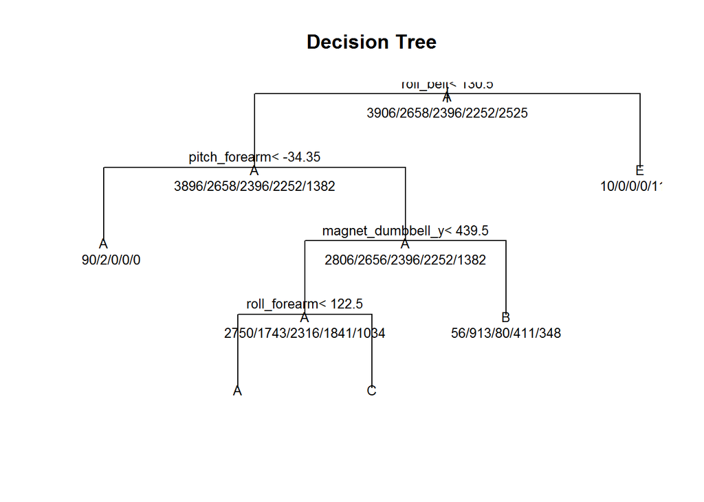

```r
set.seed(1234)

mod_rpart <- train(classe~., method = "rpart", data=train_data)
plot(mod_rpart$finalModel, uniform=TRUE, main="Decision Tree")
text(mod_rpart$finalModel, use.n=TRUE, all=TRUE, cex=.8)
```

```r
mod_gbm <- train(classe~., method = "gbm", data=train_data, verbose=FALSE)
mod_rf <- train(classe~., method = "rf", data=train_data)
```

Then we will use this model to predict on the testing data set and check the results. We will calculate the mean of correct answers. The first mean will be for the rpart model, the second mean will be for the gbm model and the final mean for the Random Forest model.

```r
mean_rpart <- mean(predict(mod_rpart, test_data) == test_data$classe) * 100
mean_rpart
```

```
## [1] 49.3288
```

```r
mean_gbm <- mean(predict(mod_gbm, test_data) == test_data$classe) * 100
mean_gbm
```

```
## [1] 96.26168
```

```r
mean_rf <- mean(predict(mod_rf, test_data) == test_data$classe) * 100
mean_rf
```

```
## [1] 99.28632
```